# My Favorite Plot

```r
library(mrvplot)
library(ggplot2)
library(dplyr)
library(ggpubr)
```

## My Favorite Plot

In genomics we are almost always plotting a large number of data points, and often looking for correlations between two variables. This vignette showcases my favorite plot, which is a hexagonal binned scatter plot that evolves from individual points to an accurate representation of data density.

## Generate Random Data

Let’s start by creating a lot random data points near the x=y line:

```r
set.seed(42) # For reproducibility
n <- 2e5

# Generate data points near the x=y line with some scatter
x <- runif(n, -1, 1)
y <- x + rnorm(n, mean = 0, sd = 0.2) # y follows x with some noise

# Constrain y values to be between -1 and 1
y <- pmax(-1, pmin(1, y))

# Create the dataset
data <- data.frame(x = x, y = y)

# Show first few points
head(data)
```

```
#>            x          y
#> 1  0.8296121  0.7467050
#> 2  0.8741508  0.8726957
#> 3 -0.4277209 -0.7905166
#> 4  0.6608953  0.4978825
#> 5  0.2834910  0.2178231
#> 6  0.0381919  0.1721512
```

## Step 1: Individual Points

Let’s start with a basic scatter plot showing all individual points:

[figure not shown]

```r
step1 <- ggplot(data, aes(x, y)) +
  geom_point(alpha = 0.3, size = 0.5) +
  labs(
    title = "Step 1: Individual Points",
    subtitle = paste(n, "points near the x=y line")
  )

print(step1)
```

I rarely even start plots at this point anymore, it is almost always useful to apply just a little styling so you can come back and use it later for a presentation, poster, or publication.

## Step 2: Add Grid Theme

My default theme is `mrv_grid()` for clean styling that has worked for me in a variety of settings. No one likes the ggplot gray background and it never works well for presentations or publications:

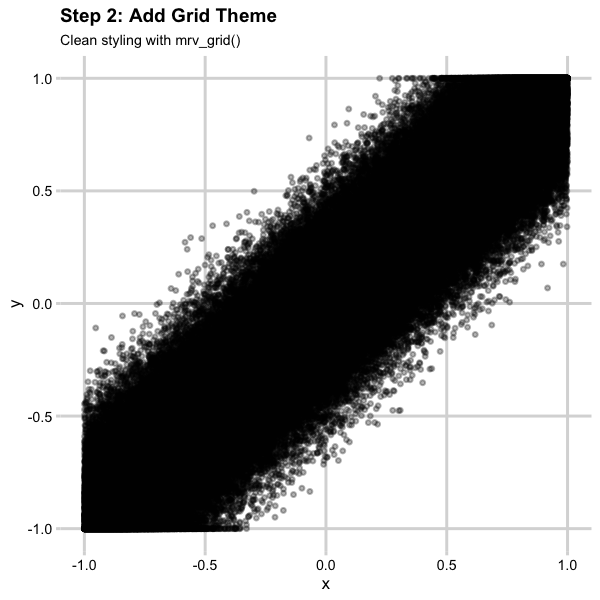

```r
step2 <- ggplot(data, aes(x, y)) +
  geom_point(alpha = 0.3, size = 0.5) +
  labs(
    title = "Step 2: Add Grid Theme",
    subtitle = "Clean styling with mrv_grid()"
  ) +
  mrv_grid()

print(step2)
```

## Step 3: Custom Axis Scales

It really is important to add proper axis labels and formatting. This is very easy with the scales package, and `scale_{x,y}_continuous`.

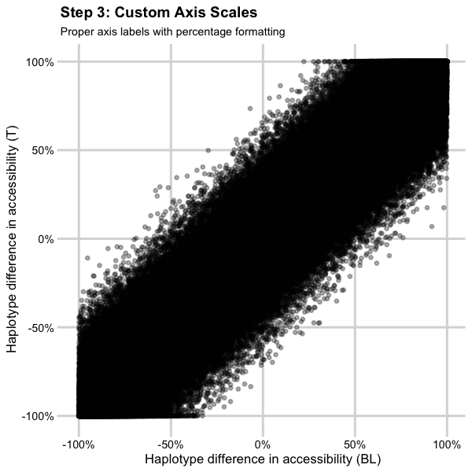

```r
step3 <- ggplot(data, aes(x, y)) +
  geom_point(alpha = 0.3, size = 0.5) +
  scale_x_continuous(
    "Haplotype difference in accessibility (BL)",
    limits = c(-1, 1),
    labels = scales::percent
  ) +
  scale_y_continuous("Haplotype difference in accessibility (T)",
    limits = c(-1, 1), labels = scales::percent
  ) +
  labs(
    title = "Step 3: Custom Axis Scales",
    subtitle = "Proper axis labels with percentage formatting"
  ) +
  mrv_grid()

print(step3)
```

## Step 4: Fixed Aspect Ratio and Reference Line

Add `coord_fixed()` and the reference line to show the x=y relationship properly. Finally, I like using the `ggpubr` function `stat_cor()` to add the correlation coefficient to the plot:

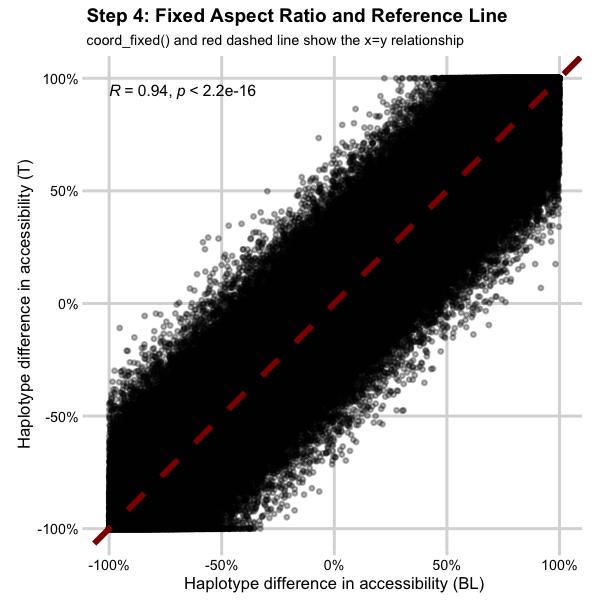

```r
step4 <- ggplot(data, aes(x, y)) +
  geom_point(alpha = 0.3, size = 0.5) +
  geom_abline(intercept = 0, slope = 1, color = "darkred", linetype = "dashed", size = 1) +
  coord_fixed() +
  stat_cor(size = 2) +
  scale_x_continuous("Haplotype difference in accessibility (BL)",
    limits = c(-1, 1), labels = scales::percent
  ) +
  scale_y_continuous("Haplotype difference in accessibility (T)",
    limits = c(-1, 1), labels = scales::percent
  ) +
  labs(
    title = "Step 4: Fixed Aspect Ratio and Reference Line",
    subtitle = "coord_fixed() and red dashed line show the x=y relationship"
  ) +
  mrv_grid()
print(step4)
```

## Step 5: Hexagonal Binning

Replace individual points with hexagonal bins to handle over-plotting:

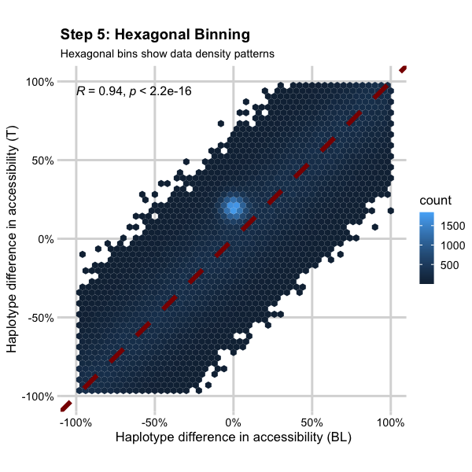

```r
step5 <- ggplot(data, aes(x, y)) +
  geom_hex(bins = 50) +
  geom_abline(intercept = 0, slope = 1, color = "darkred", linetype = "dashed", size = 1) +
  coord_fixed() +
  stat_cor(size = 2) +
  scale_x_continuous("Haplotype difference in accessibility (BL)",
    limits = c(-1, 1), labels = scales::percent
  ) +
  scale_y_continuous("Haplotype difference in accessibility (T)",
    limits = c(-1, 1), labels = scales::percent
  ) +
  labs(
    title = "Step 5: Hexagonal Binning",
    subtitle = "Hexagonal bins show data density patterns"
  ) +
  mrv_grid() +
  theme(legend.position = "right")

print(step5)
```

*Added bonus*, this is now easy to open in Adobe Illustrator or Inkscape because it doesn’t have a million individual points, just a few hexagonal bins.

## Step 6: Final - Custom Color Palette

The whole point of hexbin is that you have lots of data points, and this often means a log scale for color is much more appropriate. Adding this log scale and a nice color scheme gets you to “my favorite plot”. At least for now!

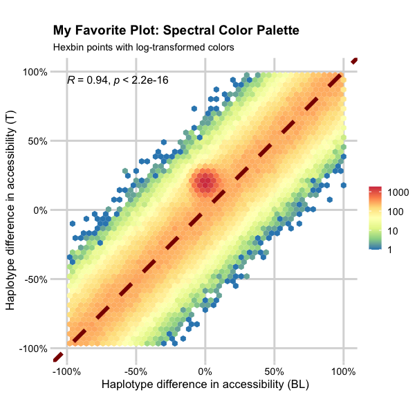

```r
favorite_plot <- ggplot(data, aes(x, y)) +
  geom_hex(bins = 50) +
  scale_fill_distiller("", palette = "Spectral", trans = "log10") +
  geom_abline(intercept = 0, slope = 1, color = "darkred", linetype = "dashed", size = 1) +
  coord_fixed() +
  stat_cor(size = 2) +
  scale_x_continuous("Haplotype difference in accessibility (BL)",
    limits = c(-1, 1), labels = scales::percent
  ) +
  scale_y_continuous("Haplotype difference in accessibility (T)",
    limits = c(-1, 1), labels = scales::percent
  ) +
  labs(
    title = "My Favorite Plot: Spectral Color Palette",
    subtitle = paste("Hexbin points with log-transformed colors")
  ) +
  mrv_grid() +
  theme(legend.position = "right")

print(favorite_plot)
```

## Saving the results

Saving the exact data that went into a plot is always important, often useful, and rarely done. The `mrv_ggsave()` function allows you to save the plot and also export the data used in the plot to a “Tables/” directory. This has become particularly useful for recent requirements in some journals that every data panel be accompanied by an excel file with the data used to create it.

`mrv_ggsave` also always saves a copy of the plot to “tmp.{ext}” where {ext} is the file extension you specify. This is useful because you can open up one file and as you run or rerun code you will see all the figure updates. I use this when working with R remotely on vscode instead of Rstudio.

Finally, when you save figure, save them with a width and height of about 3 inches. This is around the size of a journal figure panel, and it is easy to scale up or down from there. If you don’t like the look, try adjusting the size of the font, before you change the size of the figure.

```r
# Save the favorite plot with data export
mrv_ggsave("Figures/my_favorite_plot.pdf", width = 3, height = 3)
```